# NGS Analysis Basics

Author: Thomas Girke

Last update: 04 June, 2018

# 1 Overview

## 1.1 Sequence Analysis in R and Bioconductor

**R Base**

- Some basic string handling utilities. Wide spectrum of numeric data analysis tools.

**Bioconductor**

Bioconductor packages provide much more sophisticated string handling utilities for sequence analysis (Lawrence et al. 2013, Huber et al. (2015)).

- [Biostrings](http://bioconductor.org/packages/release/bioc/html/Biostrings.html): general sequence analysis environment
- [ShortRead](http://bioconductor.org/packages/release/bioc/html/ShortRead.html): pipeline for short read data
- [IRanges](http://bioconductor.org/packages/release/bioc/html/IRanges.html): low-level infrastructure for range data
- [GenomicRanges](http://bioconductor.org/packages/release/bioc/html/GenomicRanges.html): high-level infrastructure for range data
- [GenomicFeatures](http://bioconductor.org/packages/release/bioc/html/GenomicFeatures.html): managing transcript centric annotations
- [GenomicAlignments](http://bioconductor.org/packages/release/bioc/html/GenomicAlignments.html): handling short genomic alignments
- [Rsamtools](http://bioconductor.org/packages/release/bioc/html/Rsamtools.html): interface to `samtools`, `bcftools` and `tabix`
- [BSgenome](http://bioconductor.org/packages/release/bioc/html/BSgenome.html): genome annotation data
- [biomaRt](http://bioconductor.org/packages/release/bioc/html/biomaRt.html): interface to BioMart annotations
- [rtracklayer](http://bioconductor.org/packages/release/bioc/html/rtracklayer.html): Annotation imports, interface to online genome browsers
- [HelloRanges](http://bioconductor.org/packages/release/bioc/html/HelloRanges.html): Bedtools semantics in Bioc’s Ranges infrastructure

# 2 Package Requirements

Several Bioconductor packages are required for this tutorial. To install them, execute the following lines in the R console. Please also make sure that you have a recent R version installed on your system. R versions `3.3.x` or higher are recommended.

```r
source("https://bioconductor.org/biocLite.R")
biocLite(c("Biostrings", "GenomicRanges", "GenomicRanges", "rtracklayer", "systemPipeR", "seqLogo", "ShortRead"))
```

# 3 Strings in R Base

## 3.1 Basic String Matching and Parsing

### 3.1.1 String matching

Generate sample sequence data set

```r
myseq <- c("ATGCAGACATAGTG", "ATGAACATAGATCC", "GTACAGATCAC")
```

String searching with regular expression support

```r
myseq[grep("ATG", myseq)]
```

```
## [1] "ATGCAGACATAGTG" "ATGAACATAGATCC"
```

Searches `myseq` for first match of pattern “AT”

```r
pos1 <- regexpr("AT", myseq)
as.numeric(pos1); attributes(pos1)$match.length # Returns position information of matches
```

```
## [1] 1 1 7
```

```
## [1] 2 2 2
```

Searches `myseq` for all matches of pattern “AT”

```r
pos2 <- gregexpr("AT", myseq)
as.numeric(pos2[[1]]); attributes(pos2[[1]])$match.length # Returns positions of matches in first sequence
```

```
## [1] 1 9
```

```
## [1] 2 2
```

String substitution with regular expression support

```r
gsub("^ATG", "atg", myseq)
```

```
## [1] "atgCAGACATAGTG" "atgAACATAGATCC" "GTACAGATCAC"
```

### 3.1.2 Positional parsing

```r
nchar(myseq) # Computes length of strings
```

```
## [1] 14 14 11
```

```r
substring(myseq[1], c(1,3), c(2,5)) # Positional parsing of several fragments from one string
```

```
## [1] "AT"  "GCA"
```

```r
substring(myseq, c(1,4,7), c(2,6,10)) # Positional parsing of many strings
```

```
## [1] "AT"   "AAC"  "ATCA"
```

## 3.2 Random Sequence Generation

### 3.2.1 Random DNA sequences of any length

```r
rand <- sapply(1:100, function(x) paste(sample(c("A","T","G","C"), sample(10:20), replace=T), collapse=""))
rand[1:3]
```

```
## [1] "TCTCAGCAGC"           "GCCGTATCTACAGCTGCGCG" "GTAAACAAACCCT"
```

### 3.2.2 Count identical sequences

```r
table(c(rand[1:4], rand[1]))
```

```
##
## GCCGTATCTACAGCTGCGCG      GCGAACGAGGATTGG        GTAAACAAACCCT           TCTCAGCAGC
##                    1                    1                    1                    2
```

### 3.2.3 Extract reads from reference

Note: this requires `Biostrings` package.

```r
library(Biostrings)
ref <- DNAString(paste(sample(c("A","T","G","C"), 100000, replace=T), collapse=""))
randstart <- sample(1:(length(ref)-15), 1000)
randreads <- Views(ref, randstart, width=15)
rand_set <- DNAStringSet(randreads)
unlist(rand_set)
```

```
##   15000-letter "DNAString" instance
## seq: AGATTCTTTCACTCGCTCTCTAATGCTAGCCAAGCGTGGAGTACCA...GTGATGGACGAGTTTATGAAGACACGTGGGGACACAGGAAGAAAAC
```

# 4 Sequences in Bioconductor

## 4.1 Important Data Objects of Biostrings

### 4.1.1 `XString` for single sequence

- `DNAString`: for DNA
- `RNAString`: for RNA
- `AAString`: for amino acid
- `BString`: for any string

### 4.1.2 `XStringSet` for many sequences

- `DNAStringSet``: for DNA
- `RNAStringSet`: for RNA
- `AAStringSet`: for amino acid
- `BStringSet`: for any string

### 4.1.3 `QualityScaleXStringSet` for sequences with quality data

- `QualityScaledDNAStringSet`: for DNA
- `QualityScaledRNAStringSet`: for RNA
- `QualityScaledAAStringSet`: for amino acid
- `QualityScaledBStringSet`: for any string

## 4.2 Sequence Import and Export

Download the following sequences to your current working directory and then import them into R: ftp://ftp.ncbi.nlm.nih.gov/genomes/archive/old_genbank/Bacteria/Halobacterium_sp_uid217/AE004437.ffn

```r
dir.create("data", showWarnings = FALSE)
# system("wget ftp://ftp.ncbi.nlm.nih.gov/genomes/archive/old_genbank/Bacteria/Halobacterium_sp_uid217/AE004437.ffn")
download.file("ftp://ftp.ncbi.nlm.nih.gov/genomes/archive/old_genbank/Bacteria/Halobacterium_sp_uid217/AE004437.ffn", "data/AE004437.ffn")
```

Import FASTA file with `readDNAStringSet`

```r
myseq <- readDNAStringSet("data/AE004437.ffn")
myseq[1:3]
```

```
##   A DNAStringSet instance of length 3
##     width seq                                                                   names
## [1]  1206 ATGACTCGGCGGTCTCGTGTCGGTGCCGGCCTC...GTCGTCGTTGTTCGACGCTGGCGGAACCCATGA gi|12057215|gb|AE...
## [2]   666 ATGAGCATCATCGAACTCGAAGGCGTGGTCAAA...GTCAACCTCGTCGATGGGGTGTTACACACGTGA gi|12057215|gb|AE...
## [3]  1110 ATGGCGTGGCGGAACCTCGGGCGGAACCGCGTG...AACGATCCGCCCGTCGAGGCGCTCGGCGAATGA gi|12057215|gb|AE...
```

Subset sequences with regular expression on sequence name field

```r
sub <- myseq[grep("99.*", names(myseq))]
length(sub)
```

```
## [1] 170
```

Export subsetted sequences to FASTA file

```r
writeXStringSet(sub, file="./data/AE004437sub.ffn", width=80)
```

Now inspect exported sequence file `AE004437sub.ffn` in a text editor

## 4.3 Working with `XString` Containers

The `XString` stores the different types of biosequences in dedicated containers

```r
library(Biostrings)
d <- DNAString("GCATAT-TAC")
d
```

```
##   10-letter "DNAString" instance
## seq: GCATAT-TAC
```

```r
d[1:4]
```

```
##   4-letter "DNAString" instance
## seq: GCAT
```

RNA sequences

```r
r <- RNAString("GCAUAU-UAC")
r <- RNAString(d) # Converts d to RNAString object
r
```

```
##   10-letter "RNAString" instance
## seq: GCAUAU-UAC
```

Protein sequences

```r
p <- AAString("HCWYHH")
p
```

```
##   6-letter "AAString" instance
## seq: HCWYHH
```

Any type of character strings

```r
b <- BString("I store any set of characters. Other XString objects store only the IUPAC characters.")
b
```

```
##   85-letter "BString" instance
## seq: I store any set of characters. Other XString objects store only the IUPAC characters.
```

## 4.4 Working with `XStringSet` Containers

`XStringSet` containers allow to store many biosequences in one object

```r
dset <- DNAStringSet(c("GCATATTAC", "AATCGATCC", "GCATATTAC"))
names(dset) <- c("seq1", "seq2", "seq3") # Assigns names
dset[1:2]
```

```
##   A DNAStringSet instance of length 2
##     width seq                                                                   names
## [1]     9 GCATATTAC                                                             seq1
## [2]     9 AATCGATCC                                                             seq2
```

Important utilities for `XStringSet` containers

```r
width(dset) # Returns the length of each sequences
```

```
## [1] 9 9 9
```

```r
d <- dset[[1]] # The [[ subsetting operator returns a single entry as XString object
dset2 <- c(dset, dset) # Appends/concatenates two XStringSet objects
dsetchar <- as.character(dset) # Converts XStringSet to named vector
dsetone <- unlist(dset) # Collapses many sequences to a single one stored in a DNAString container
```

Sequence subsetting by positions:

```r
DNAStringSet(dset, start=c(1,2,3), end=c(4,8,5))
```

```
##   A DNAStringSet instance of length 3
##     width seq                                                                   names
## [1]     4 GCAT                                                                  seq1
## [2]     7 ATCGATC                                                               seq2
## [3]     3 ATA                                                                   seq3
```

## 4.5 Multiple Alignment Class

The `XMultipleAlignment` class stores the different types of multiple sequence alignments:

```r
origMAlign <- readDNAMultipleAlignment(filepath = system.file("extdata",
              "msx2_mRNA.aln", package = "Biostrings"), format = "clustal")
origMAlign
```

```
## DNAMultipleAlignment with 8 rows and 2343 columns
##      aln                                                                        names
## [1] -----TCCCGTCTCCGCAGCAAAAAAGTTTGAGTCG...TTGTCCAAACTCACAATTAAAAAAAAAAAAAAAAA gi|84452153|ref|N...
## [2] ------------------------------------...----------------------------------- gi|208431713|ref|...
## [3] ------------------------------------...----------------------------------- gi|118601823|ref|...
## [4] ----------------------AAAAGTTGGAGTCT...----------------------------------- gi|114326503|ref|...
## [5] ------------------------------------...----------------------------------- gi|119220589|ref|...
## [6] ------------------------------------...----------------------------------- gi|148540149|ref|...
## [7] --------------CGGCTCCGCAGCGCCTCACTCG...----------------------------------- gi|45383056|ref|N...
## [8] GGGGGAGACTTCAGAAGTTGTTGTCCTCTCCGCTGA...----------------------------------- gi|213515133|ref|...
```

## 4.6 Basic Sequence Manipulations

### 4.6.1 Reverse and Complement

```r
randset <- DNAStringSet(rand)
complement(randset[1:2])
```

```
##   A DNAStringSet instance of length 2
##     width seq
## [1]    10 AGAGTCGTCG
## [2]    20 CGGCATAGATGTCGACGCGC
```

```r
reverse(randset[1:2])
```

```
##   A DNAStringSet instance of length 2
##     width seq
## [1]    10 CGACGACTCT
## [2]    20 GCGCGTCGACATCTATGCCG
```

```r
reverseComplement(randset[1:2])
```

```
##   A DNAStringSet instance of length 2
##     width seq
## [1]    10 GCTGCTGAGA
## [2]    20 CGCGCAGCTGTAGATACGGC
```

## 4.7 Translate DNA into Protein

```r
translate(randset[1:2])
```

```
##   A AAStringSet instance of length 2
##     width seq
## [1]     3 SQQ
## [2]     6 AVSTAA
```

## 4.8 Pattern Matching

### 4.8.1 Pattern matching with mismatches

Find pattern matches in reference

```r
myseq1 <- readDNAStringSet("./data/AE004437.ffn")
mypos <- matchPattern("ATGGTG", myseq1[[1]], max.mismatch=1)
```

Count only the corresponding matches

```r
countPattern("ATGGCT", myseq1[[1]], max.mismatch=1)
```

```
## [1] 3
```

Count matches in many sequences

```r
vcountPattern("ATGGCT", myseq1, max.mismatch=1)[1:20]
```

```
##  [1] 3 0 5 4 1 2 2 1 4 3 0 0 1 2 0 1 4 0 0 1
```

Results shown in DNAStringSet object

```r
tmp <- c(DNAStringSet("ATGGTG"), DNAStringSet(mypos))
```

Return a consensus matrix for query and hits

```r
consensusMatrix(tmp)[1:4,]
```

```
##   [,1] [,2] [,3] [,4] [,5] [,6]
## A    3    0    0    0    0    0
## C    1    1    0    0    0    0
## G    0    0    4    4    1    4
## T    0    3    0    0    3    0
```

Find all pattern matches in reference

```r
myvpos <- vmatchPattern("ATGGCT", myseq1, max.mismatch=1)
myvpos # The results are stored as MIndex object.
```

```
## MIndex object of length 2058
## $`gi|12057215|gb|AE004437.1|:248-1453 Halobacterium sp. NRC-1, complete genome`
## IRanges object with 3 ranges and 0 metadata columns:
##           start       end     width
##       <integer> <integer> <integer>
##   [1]         1         6         6
##   [2]       383       388         6
##   [3]       928       933         6
##
## $`gi|12057215|gb|AE004437.1|:1450-2115 Halobacterium sp. NRC-1, complete genome`
## IRanges object with 0 ranges and 0 metadata columns:
##        start       end     width
##    <integer> <integer> <integer>
##
## $`gi|12057215|gb|AE004437.1|:2145-3254 Halobacterium sp. NRC-1, complete genome`
## IRanges object with 5 ranges and 0 metadata columns:
##           start       end     width
##       <integer> <integer> <integer>
##   [1]         1         6         6
##   [2]        94        99         6
##   [3]       221       226         6
##   [4]       535       540         6
##   [5]       601       606         6
##
## ...
## <2055 more elements>
```

```r
Views(myseq1[[1]], start(myvpos[[1]]), end(myvpos[[1]])) # Retrieves the result for single entry
```

```
##   Views on a 1206-letter DNAString subject
## subject: ATGACTCGGCGGTCTCGTGTCGGTGCCGGCCTCGCAGCCATTGT...TTGCGATCGTCGTCGTCGTTGTTCGACGCTGGCGGAACCCATGA
## views:
##     start end width
## [1]     1   6     6 [ATGACT]
## [2]   383 388     6 [ATGGCA]
## [3]   928 933     6 [ATGACT]
```

Return all matches

```r
sapply(seq(along=myseq1), function(x)
       as.character(Views(myseq1[[x]], start(myvpos[[x]]), end(myvpos[[x]]))))[1:4]
```

[output not shown]

### 4.8.2 Pattern matching with regular expression support

```r
myseq <- DNAStringSet(c("ATGCAGACATAGTG", "ATGAACATAGATCC", "GTACAGATCAC"))
myseq[grep("^ATG", myseq, perl=TRUE)] # String searching with regular expression support
```

```
##   A DNAStringSet instance of length 2
##     width seq
## [1]    14 ATGCAGACATAGTG
## [2]    14 ATGAACATAGATCC
```

```r
pos1 <- regexpr("AT", myseq) # Searches 'myseq' for first match of pattern "AT"
as.numeric(pos1); attributes(pos1)$match.length # Returns position information of matches
```

```
## [1] 1 1 7
```

```
## [1] 2 2 2
```

```r
pos2 <- gregexpr("AT", myseq) # Searches 'myseq' for all matches of pattern "AT"
as.numeric(pos2[[1]]); attributes(pos2[[1]])$match.length # Match positions in first sequence
```

```
## [1] 1 9
```

```
## [1] 2 2
```

```r
DNAStringSet(gsub("^ATG", "NNN", myseq)) # String substitution with regular expression support
```

```
##   A DNAStringSet instance of length 3
##     width seq
## [1]    14 NNNCAGACATAGTG
## [2]    14 NNNAACATAGATCC
## [3]    11 GTACAGATCAC
```

## 4.9 PWM Viewing and Searching

### 4.9.1 Plot with `seqLogo`

```r
library(seqLogo)
pwm <- PWM(DNAStringSet(c("GCT", "GGT", "GCA")))
pwm
```

```
##        [,1]      [,2]      [,3]
## A 0.0000000 0.0000000 0.2312611
## C 0.0000000 0.3157205 0.0000000
## G 0.3685591 0.2312611 0.0000000
## T 0.0000000 0.0000000 0.3157205
```

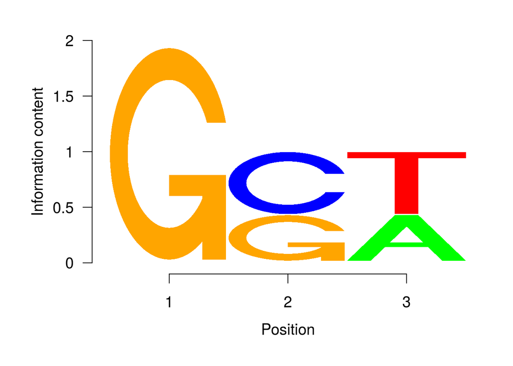

```r
seqLogo(t(t(pwm) * 1/colSums(pwm)))
```

### 4.9.2 Plot with `ggseqlogo`

The `ggseqlogo` package ([manual](https://omarwagih.github.io/ggseqlogo/)) provides many customization options for plotting sequence logos. It also supports various alphabets including sequence logos for amino acid sequences.

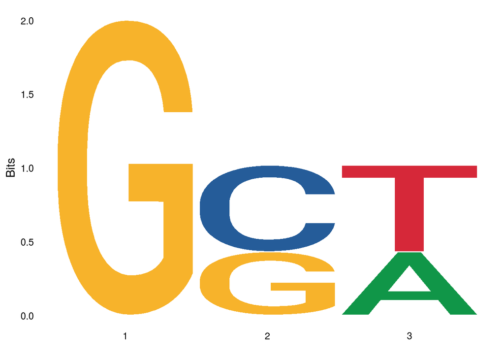

```r
library(ggplot2); library(ggseqlogo)
pwm <- PWM(DNAStringSet(c("GCT", "GGT", "GCA")))
ggseqlogo(pwm)
```

Search sequence for PWM matches with score better than `min.score`

```r
chr <- DNAString("AAAGCTAAAGGTAAAGCAAAA")
matchPWM(pwm, chr, min.score=0.9)
```

```
##   Views on a 21-letter DNAString subject
## subject: AAAGCTAAAGGTAAAGCAAAA
## views:
##     start end width
## [1]     4   6     3 [GCT]
## [2]    10  12     3 [GGT]
## [3]    16  18     3 [GCA]
```

# 5 NGS Sequences

## 5.1 Sequence and Quality Data: FASTQ Format

Four lines per sequence:

1. ID
2. Sequence
3. ID
4. Base call qualities (Phred scores) as ASCII characters

The following gives an example of 3 Illumina reads in a FASTQ file. The numbers at the beginning of each line are not part of the FASTQ format. They have been added solely for illustration purposes.

```
1. @SRR038845.3 HWI-EAS038:6:1:0:1938 length=36
2. CAACGAGTTCACACCTTGGCCGACAGGCCCGGGTAA
3. +SRR038845.3 HWI-EAS038:6:1:0:1938 length=36
4. BA@7>B=>:>>7@7@>>9=BAA?;>52;>:9=8.=A
1. @SRR038845.41 HWI-EAS038:6:1:0:1474 length=36
2. CCAATGATTTTTTTCCGTGTTTCAGAATACGGTTAA
3. +SRR038845.41 HWI-EAS038:6:1:0:1474 length=36
4. BCCBA@BB@BBBBAB@B9B@=BABA@A:@693:@B=
1. @SRR038845.53 HWI-EAS038:6:1:1:360 length=36
2. GTTCAAAAAGAACTAAATTGTGTCAATAGAAAACTC
3. +SRR038845.53 HWI-EAS038:6:1:1:360 length=36
4. BBCBBBBBB@@BAB?BBBBCBC>BBBAA8>BBBAA@
```

## 5.2 Sequence and Quality Data: `QualityScaleXStringSet`

Phred quality scores are integers from 0-50 that are stored as ASCII characters after adding 33. The basic R functions `rawToChar` and `charToRaw` can be used to interconvert among their representations.

Phred score interconversion

```r
phred <- 1:9
phreda <- paste(sapply(as.raw((phred)+33), rawToChar), collapse="")
phreda
```

```
## [1] "\"#$%&'()*"
```

```r
as.integer(charToRaw(phreda))-33
```

```
## [1] 1 2 3 4 5 6 7 8 9
```

Construct `QualityScaledDNAStringSet` from scratch

```r
dset <- DNAStringSet(sapply(1:100, function(x) paste(sample(c("A","T","G","C"), 20, replace=T), collapse=""))) # Creates random sample sequence.
myqlist <- lapply(1:100, function(x) sample(1:40, 20, replace=T)) # Creates random Phred score list.
myqual <- sapply(myqlist, function(x) toString(PhredQuality(x))) # Converts integer scores into ASCII characters.
myqual <- PhredQuality(myqual) # Converts to a PhredQuality object.
dsetq1 <- QualityScaledDNAStringSet(dset, myqual) # Combines DNAStringSet and quality data in QualityScaledDNAStringSet object.
dsetq1[1:2]
```

```
##   A QualityScaledDNAStringSet instance containing:
##
##   A DNAStringSet instance of length 2
##     width seq
## [1]    20 TAAAAACTTATTAGGGATGG
## [2]    20 TAAATACACACTCTCAACCA
##
##   A PhredQuality instance of length 2
##     width seq
## [1]    20 CBAADAF?)2#?)AED6#5.
## [2]    20 HD7CE.$.8*%=B#<(3%G)
```

## 5.3 Processing FASTQ Files with ShortRead

The following expains the basic usage of `ShortReadQ` objects. To make the sample code work, download and unzip this [file](http://faculty.ucr.edu/~tgirke/HTML_Presentations/Manuals/Workshop_Dec_6_10_2012/Rsequences/data.zip) to your current working directory. The following code performs the download for you.

```r
library(ShortRead)
download.file("http://faculty.ucr.edu/~tgirke/HTML_Presentations/Manuals/Workshop_Dec_6_10_2012/Rsequences/data.zip", "data.zip")
unzip("data.zip")
```

Important utilities for accessing FASTQ files

```r
fastq <- list.files("data", "*.fastq$"); fastq <- paste("data/", fastq, sep="")
names(fastq) <- paste("flowcell6_lane", 1:length(fastq), sep="_")
(fq <- readFastq(fastq[1])) # Imports first FASTQ file
```

```
## class: ShortReadQ
## length: 1000 reads; width: 36 cycles
```

```r
countLines(dirPath="./data", pattern=".fastq$")/4 # Counts numbers of reads in FASTQ files
```

```
## SRR038845.fastq SRR038846.fastq SRR038848.fastq SRR038850.fastq
##            1000            1000            1000            1000
```

```r
id(fq)[1] # Returns ID field
```

```
##   A BStringSet instance of length 1
##     width seq
## [1]    43 SRR038845.3 HWI-EAS038:6:1:0:1938 length=36
```

```r
sread(fq)[1] # Returns sequence
```

```
##   A DNAStringSet instance of length 1
##     width seq
## [1]    36 CAACGAGTTCACACCTTGGCCGACAGGCCCGGGTAA
```

```r
quality(fq)[1] # Returns Phred scores
```

```
## class: FastqQuality
## quality:
##   A BStringSet instance of length 1
##     width seq
## [1]    36 BA@7>B=>:>>7@7@>>9=BAA?;>52;>:9=8.=A
```

```r
as(quality(fq), "matrix")[1:4,1:12] # Coerces Phred scores to numeric matrix
```

```
##      [,1] [,2] [,3] [,4] [,5] [,6] [,7] [,8] [,9] [,10] [,11] [,12]
## [1,]   33   32   31   22   29   33   28   29   25    29    29    22
## [2,]   33   34   34   33   32   31   33   33   31    33    33    33
## [3,]   33   33   34   33   33   33   33   33   33    31    31    33
## [4,]   33   33   33   33   31   33   28   31   28    32    33    33
```

```r
ShortReadQ(sread=sread(fq), quality=quality(fq), id=id(fq)) # Constructs a ShortReadQ from components
```

```
## class: ShortReadQ
## length: 1000 reads; width: 36 cycles
```

## 5.4 FASTQ Quality Reports

### 5.4.1 Using `systemPipeR`

The following `seeFastq` and `seeFastqPlot` functions generate and plot a series of useful quality statistics for a set of FASTQ files.

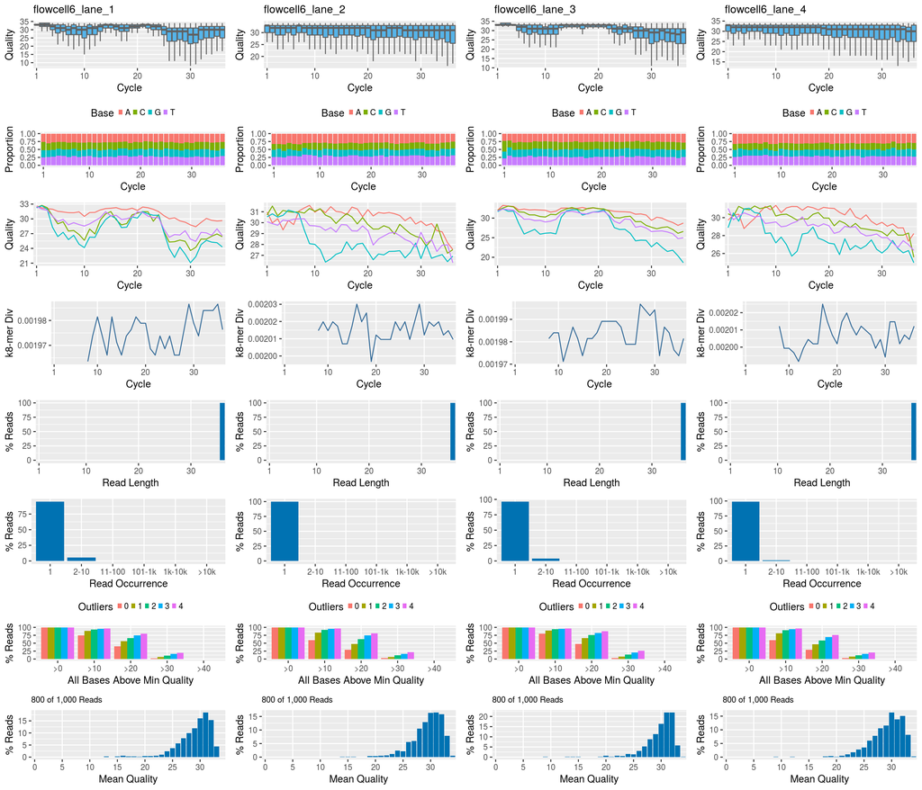

```r
library(systemPipeR)
fqlist <- seeFastq(fastq=fastq, batchsize=800, klength=8) # For real data set batchsize to at least 10^5
seeFastqPlot(fqlist)
```

Handles many samples in one PDF file. For more details see [here](http://bioconductor.org/packages/devel/bioc/vignettes/systemPipeR/inst/doc/systemPipeR.html)

### 5.4.2 Using `ShortRead`

The `ShortRead` package contains several FASTQ quality reporting functions.

```r
sp <- SolexaPath(system.file('extdata', package='ShortRead'))
fl <- file.path(analysisPath(sp), "s_1_sequence.txt")
fls <- c(fl, fl)
coll <- QACollate(QAFastqSource(fls), QAReadQuality(), QAAdapterContamination(),
        QANucleotideUse(), QAQualityUse(), QASequenceUse(), QAFrequentSequence(n=10),
        QANucleotideByCycle(), QAQualityByCycle())
x <- qa2(coll, verbose=TRUE)
res <- report(x)
if(interactive())
browseURL(res)
```

## 5.5 Filtering and Trimming FASTQ Files with ShortRead

### 5.5.1 Adaptor trimming

```r
fqtrim <- trimLRPatterns(Rpattern="GCCCGGGTAA", subject=fq)
sread(fq)[1:2] # Before trimming
```

```
##   A DNAStringSet instance of length 2
##     width seq
## [1]    36 CAACGAGTTCACACCTTGGCCGACAGGCCCGGGTAA
## [2]    36 CCAATGATTTTTTTCCGTGTTTCAGAATACGGTTAA
```

```r
sread(fqtrim)[1:2] # After trimming
```

```
##   A DNAStringSet instance of length 2
##     width seq
## [1]    26 CAACGAGTTCACACCTTGGCCGACAG
## [2]    36 CCAATGATTTTTTTCCGTGTTTCAGAATACGGTTAA
```

### 5.5.2 Read counting and duplicate removal

```r
tables(fq)$distribution # Counts read occurences
```

```
##   nOccurrences nReads
## 1            1    948
## 2            2     26
```

```r
sum(srduplicated(fq)) # Identifies duplicated reads
```

```
## [1] 26
```

```r
fq[!srduplicated(fq)]
```

```
## class: ShortReadQ
## length: 974 reads; width: 36 cycles
```

### 5.5.3 Trimming low quality tails

```r
cutoff <- 30
cutoff <- rawToChar(as.raw(cutoff+33))
sread(trimTails(fq, k=2, a=cutoff, successive=FALSE))[1:2]
```

```
##   A DNAStringSet instance of length 2
##     width seq
## [1]     4 CAAC
## [2]    20 CCAATGATTTTTTTCCGTGT
```

### 5.5.4 Removal of reads with Phred scores below a threshold value

```r
cutoff <- 30
qcount <- rowSums(as(quality(fq), "matrix") <= 20)
fq[qcount == 0] # Number of reads where all Phred scores >= 20
```

```
## class: ShortReadQ
## length: 349 reads; width: 36 cycles
```

### 5.5.5 Removal of reads with x Ns and/or low complexity segments

```r
filter1 <- nFilter(threshold=1) # Keeps only reads without Ns
filter2 <- polynFilter(threshold=20, nuc=c("A","T","G","C")) # Removes reads with >=20 of one nucleotide
filter <- compose(filter1, filter2)
fq[filter(fq)]
```

```
## class: ShortReadQ
## length: 989 reads; width: 36 cycles
```

## 5.6 Memory Efficient FASTQ Processing

Streaming through FASTQ files with `FastqStreamer` and random sampling reads with `FastqSampler`

```r
fq <- yield(FastqStreamer(fastq[1], 50)) # Imports first 50 reads
fq <- yield(FastqSampler(fastq[1], 50)) # Random samples 50 reads
```

Streaming through a FASTQ file while applying filtering/trimming functions and writing the results to a new file here `SRR038845.fastq_sub` in `data` directory.

```r
f <- FastqStreamer(fastq[1], 50)
while(length(fq <- yield(f))) {
    fqsub <- fq[grepl("^TT", sread(fq))]
    writeFastq(fqsub, paste(fastq[1], "sub", sep="_"), mode="a", compress=FALSE)
}
close(f)
```

# 6 Range Operations

## 6.1 Important Data Objects for Range Operations

- `IRanges`: stores range data only (IRanges library)
- `GRanges`: stores ranges and annotations (GenomicRanges library)
- `GRangesList`: list version of GRanges container (GenomicRanges library)

## 6.2 Range Data Are Stored in `IRanges` and `GRanges` Containers

### 6.2.1 Construct `GRanges` Object

```r
library(GenomicRanges); library(rtracklayer)
gr <- GRanges(seqnames = Rle(c("chr1", "chr2", "chr1", "chr3"), c(1, 3, 2, 4)), ranges = IRanges(1:10, end = 7:16, names = head(letters, 10)), strand = Rle(strand(c("-", "+", "*", "+", "-")), c(1, 2, 2, 3, 2)), score = 1:10, GC = seq(1, 0, length = 10)) # Example of creating a GRanges object with its constructor function.
```

### 6.2.2 Import GFF into `GRanges` Object

```r
gff <- import.gff("http://faculty.ucr.edu/~tgirke/Documents/R_BioCond/Samples/gff3.gff") # Imports a simplified GFF3 genome annotation file.
seqlengths(gff) <- end(ranges(gff[which(values(gff)[,"type"]=="chromosome"),]))
names(gff) <- 1:length(gff) # Assigns names to corresponding slot
gff[1:4,]
```

```
## GRanges object with 4 ranges and 10 metadata columns:
##     seqnames           ranges strand |   source       type     score     phase                  ID
##        <Rle>        <IRanges>  <Rle> | <factor>   <factor> <numeric> <integer>         <character>
##   1     Chr1 [   1, 30427671]      + |   TAIR10 chromosome      <NA>      <NA>                Chr1
##   2     Chr1 [3631,     5899]      + |   TAIR10       gene      <NA>      <NA>           AT1G01010
##   3     Chr1 [3631,     5899]      + |   TAIR10       mRNA      <NA>      <NA>         AT1G01010.1
##   4     Chr1 [3760,     5630]      + |   TAIR10    protein      <NA>      <NA> AT1G01010.1-Protein
##            Name                Note          Parent       Index Derives_from
##     <character>     <CharacterList> <CharacterList> <character>  <character>
##   1        Chr1                                            <NA>         <NA>
##   2   AT1G01010 protein_coding_gene                        <NA>         <NA>
##   3 AT1G01010.1                           AT1G01010           1         <NA>
##   4 AT1G01010.1                                            <NA>  AT1G01010.1
##   -------
##   seqinfo: 7 sequences from an unspecified genome
```

### 6.2.3 Coerce `GRanges` object to `data.frame`

```r
as.data.frame(gff)[1:4, 1:7]
```

```
##   seqnames start      end    width strand source       type
## 1     Chr1     1 30427671 30427671      + TAIR10 chromosome
## 2     Chr1  3631     5899     2269      + TAIR10       gene
## 3     Chr1  3631     5899     2269      + TAIR10       mRNA
## 4     Chr1  3760     5630     1871      + TAIR10    protein
```

### 6.2.4 Coerce `GRanges` to `RangedData` object and vice versa

```r
gff_rd <- as(gff, "RangedData")
gff_gr <- as(gff_rd, "GRanges")
```

## 6.3 Utilities for Range Containers

### 6.3.1 Accessor and subsetting methods for GRanges objects

Subsetting and replacement

```r
gff[1:4]
```

```
## GRanges object with 4 ranges and 10 metadata columns:
##     seqnames           ranges strand |   source       type     score     phase                  ID
##        <Rle>        <IRanges>  <Rle> | <factor>   <factor> <numeric> <integer>         <character>
##   1     Chr1 [   1, 30427671]      + |   TAIR10 chromosome      <NA>      <NA>                Chr1
##   2     Chr1 [3631,     5899]      + |   TAIR10       gene      <NA>      <NA>           AT1G01010
##   3     Chr1 [3631,     5899]      + |   TAIR10       mRNA      <NA>      <NA>         AT1G01010.1
##   4     Chr1 [3760,     5630]      + |   TAIR10    protein      <NA>      <NA> AT1G01010.1-Protein
##            Name                Note          Parent       Index Derives_from
##     <character>     <CharacterList> <CharacterList> <character>  <character>
##   1        Chr1                                            <NA>         <NA>
##   2   AT1G01010 protein_coding_gene                        <NA>         <NA>
##   3 AT1G01010.1                           AT1G01010           1         <NA>
##   4 AT1G01010.1                                            <NA>  AT1G01010.1
##   -------
##   seqinfo: 7 sequences from an unspecified genome
```

```r
gff[1:4, c("type", "ID")]
```

```
## GRanges object with 4 ranges and 2 metadata columns:
##     seqnames           ranges strand |       type                  ID
##        <Rle>        <IRanges>  <Rle> |   <factor>         <character>
##   1     Chr1 [   1, 30427671]      + | chromosome                Chr1
##   2     Chr1 [3631,     5899]      + |       gene           AT1G01010
##   3     Chr1 [3631,     5899]      + |       mRNA         AT1G01010.1
##   4     Chr1 [3760,     5630]      + |    protein AT1G01010.1-Protein
##   -------
##   seqinfo: 7 sequences from an unspecified genome
```

```r
gff[2] <- gff[3]
```

GRanges objects can be concatenated with the `c` function

```r
c(gff[1:2], gff[401:402])
```

```
## GRanges object with 4 ranges and 10 metadata columns:
##       seqnames           ranges strand |   source           type     score     phase
##          <Rle>        <IRanges>  <Rle> | <factor>       <factor> <numeric> <integer>
##     1     Chr1 [   1, 30427671]      + |   TAIR10     chromosome      <NA>      <NA>
##     2     Chr1 [3631,     5899]      + |   TAIR10           mRNA      <NA>      <NA>
##   401     Chr5 [5516,     5769]      - |   TAIR10        protein      <NA>      <NA>
##   402     Chr5 [5770,     5801]      - |   TAIR10 five_prime_UTR      <NA>      <NA>
##                        ID        Name            Note          Parent       Index Derives_from
##               <character> <character> <CharacterList> <CharacterList> <character>  <character>
##     1                Chr1        Chr1                                        <NA>         <NA>
##     2         AT1G01010.1 AT1G01010.1                       AT1G01010           1         <NA>
##   401 AT5G01015.2-Protein AT5G01015.2                                        <NA>  AT5G01015.2
##   402                <NA>        <NA>                     AT5G01015.2        <NA>         <NA>
##   -------
##   seqinfo: 7 sequences from an unspecified genome
```

Acessor functions

```r
seqnames(gff)
```

```
## factor-Rle of length 449 with 7 runs
##   Lengths:   72   22   38  118  172   13   14
##   Values : Chr1 Chr2 Chr3 Chr4 Chr5 ChrC ChrM
## Levels(7): Chr1 Chr2 Chr3 Chr4 Chr5 ChrC ChrM
```

```r
ranges(gff)
```

```
## IRanges object with 449 ranges and 0 metadata columns:
##           start       end     width
##       <integer> <integer> <integer>
##     1         1  30427671  30427671
##     2      3631      5899      2269
##     3      3631      5899      2269
##     4      3760      5630      1871
##     5      3631      3913       283
##   ...       ...       ...       ...
##   445     11918     12241       324
##   446     11918     12241       324
##   447     11918     12241       324
##   448     11918     12241       324
##   449     11918     12241       324
```

```r
strand(gff)
```

```
## factor-Rle of length 449 with 13 runs
##   Lengths:  18  54  28  21  12 117   1 171   1  12   1   8   5
##   Values :   +   -   +   -   +   -   +   -   +   -   +   -   +
## Levels(3): + - *
```

```r
seqlengths(gff)
```

```
##     Chr1     Chr2     Chr3     Chr4     Chr5     ChrC     ChrM
## 30427671 19698289 23459830 18585056 26975502   154478   366924
```

```r
start(gff[1:4])
```

```
## [1]    1 3631 3631 3760
```

```r
end(gff[1:4])
```

```
## [1] 30427671     5899     5899     5630
```

```r
width(gff[1:4])
```

```
## [1] 30427671     2269     2269     1871
```

Accessing metadata component

```r
values(gff) # or elementMetadata(gff)
```

```
## DataFrame with 449 rows and 10 columns
##       source       type     score     phase                  ID        Name                Note
##     <factor>   <factor> <numeric> <integer>         <character> <character>     <CharacterList>
## 1     TAIR10 chromosome        NA        NA                Chr1        Chr1
## 2     TAIR10       mRNA        NA        NA         AT1G01010.1 AT1G01010.1
## 3     TAIR10       mRNA        NA        NA         AT1G01010.1 AT1G01010.1
## 4     TAIR10    protein        NA        NA AT1G01010.1-Protein AT1G01010.1
## 5     TAIR10       exon        NA        NA                  NA          NA
## ...      ...        ...       ...       ...                 ...         ...                 ...
## 445   TAIR10       gene        NA        NA           ATMG00030   ATMG00030 protein_coding_gene
## 446   TAIR10       mRNA        NA        NA         ATMG00030.1 ATMG00030.1
## 447   TAIR10    protein        NA        NA ATMG00030.1-Protein ATMG00030.1
## 448   TAIR10       exon        NA        NA                  NA          NA
## 449   TAIR10        CDS        NA         0                  NA          NA
##                              Parent       Index Derives_from
##                     <CharacterList> <character>  <character>
## 1                                            NA           NA
## 2                         AT1G01010           1           NA
## 3                         AT1G01010           1           NA
## 4                                            NA  AT1G01010.1
## 5                       AT1G01010.1          NA           NA
## ...                             ...         ...          ...
## 445                                          NA           NA
## 446                       ATMG00030           1           NA
## 447                                          NA  ATMG00030.1
## 448                     ATMG00030.1          NA           NA
## 449 ATMG00030.1,ATMG00030.1-Protein          NA           NA
```

```r
values(gff)[, "type"][1:20]
```

```
##  [1] chromosome      mRNA            mRNA            protein         exon            five_prime_UTR
##  [7] CDS             exon            CDS             exon            CDS             exon
## [13] CDS             exon            CDS             exon            CDS             three_prime_UTR
## [19] gene            mRNA
## Levels: chromosome gene mRNA protein exon five_prime_UTR CDS three_prime_UTR rRNA tRNA
```

```r
gff[values(gff)[ ,"type"] == "gene"]
```

```
## GRanges object with 21 ranges and 10 metadata columns:
##       seqnames         ranges strand |   source     type     score     phase          ID
##          <Rle>      <IRanges>  <Rle> | <factor> <factor> <numeric> <integer> <character>
##    19     Chr1 [ 5928,  8737]      - |   TAIR10     gene      <NA>      <NA>   AT1G01020
##    64     Chr1 [11649, 13714]      - |   TAIR10     gene      <NA>      <NA>   AT1G01030
##    74     Chr2 [ 1025,  2810]      + |   TAIR10     gene      <NA>      <NA>   AT2G01008
##    84     Chr2 [ 3706,  5513]      + |   TAIR10     gene      <NA>      <NA>   AT2G01010
##    87     Chr2 [ 5782,  5945]      + |   TAIR10     gene      <NA>      <NA>   AT2G01020
##   ...      ...            ...    ... .      ...      ...       ...       ...         ...
##   427     ChrC [  383,  1444]      - |   TAIR10     gene      <NA>      <NA>   ATCG00020
##   432     ChrC [ 1717,  4347]      - |   TAIR10     gene      <NA>      <NA>   ATCG00030
##   437     ChrM [  273,   734]      - |   TAIR10     gene      <NA>      <NA>   ATMG00010
##   442     ChrM [ 8848, 11415]      - |   TAIR10     gene      <NA>      <NA>   ATMG00020
##   445     ChrM [11918, 12241]      + |   TAIR10     gene      <NA>      <NA>   ATMG00030
##              Name                Note          Parent       Index Derives_from
##       <character>     <CharacterList> <CharacterList> <character>  <character>
##    19   AT1G01020 protein_coding_gene                        <NA>         <NA>
##    64   AT1G01030 protein_coding_gene                        <NA>         <NA>
##    74   AT2G01008 protein_coding_gene                        <NA>         <NA>
##    84   AT2G01010                rRNA                        <NA>         <NA>
##    87   AT2G01020                rRNA                        <NA>         <NA>
##   ...         ...                 ...             ...         ...          ...
##   427   ATCG00020 protein_coding_gene                        <NA>         <NA>
##   432   ATCG00030                tRNA                        <NA>         <NA>
##   437   ATMG00010 protein_coding_gene                        <NA>         <NA>
##   442   ATMG00020                rRNA                        <NA>         <NA>
##   445   ATMG00030 protein_coding_gene                        <NA>         <NA>
##   -------
##   seqinfo: 7 sequences from an unspecified genome
```

### 6.3.2 Useful utilities for GRanges objects

Remove chromosome ranges

```r
gff <- gff[values(gff)$type != "chromosome"]
```

Erase the strand information

```r
strand(gff) <- "*"
```

Collapses overlapping ranges to continuous ranges.

```r
reduce(gff)
```

```
## GRanges object with 22 ranges and 0 metadata columns:
##        seqnames         ranges strand
##           <Rle>      <IRanges>  <Rle>
##    [1]     Chr1 [ 3631,  5899]      *
##    [2]     Chr1 [ 5928,  8737]      *
##    [3]     Chr1 [11649, 13714]      *
##    [4]     Chr2 [ 1025,  2810]      *
##    [5]     Chr2 [ 3706,  5513]      *
##    ...      ...            ...    ...
##   [18]     ChrC [  383,  1444]      *
##   [19]     ChrC [ 1717,  4347]      *
##   [20]     ChrM [  273,   734]      *
##   [21]     ChrM [ 8848, 11415]      *
##   [22]     ChrM [11918, 12241]      *
##   -------
##   seqinfo: 7 sequences from an unspecified genome
```

Return uncovered regions

```r
gaps(gff)
```

```
## GRanges object with 43 ranges and 0 metadata columns:
##        seqnames           ranges strand
##           <Rle>        <IRanges>  <Rle>
##    [1]     Chr1 [   1, 30427671]      +
##    [2]     Chr1 [   1, 30427671]      -
##    [3]     Chr1 [   1,     3630]      *
##    [4]     Chr1 [5900,     5927]      *
##    [5]     Chr1 [8738,    11648]      *
##    ...      ...              ...    ...
##   [39]     ChrM  [    1, 366924]      -
##   [40]     ChrM  [    1,    272]      *
##   [41]     ChrM  [  735,   8847]      *
##   [42]     ChrM  [11416,  11917]      *
##   [43]     ChrM  [12242, 366924]      *
##   -------
##   seqinfo: 7 sequences from an unspecified genome
```

More intuitive way to get uncovered regions

```r
setdiff(as(seqinfo(gff), "GRanges"), gff)
```

```
## GRanges object with 29 ranges and 0 metadata columns:
##        seqnames            ranges strand
##           <Rle>         <IRanges>  <Rle>
##    [1]     Chr1 [    1,     3630]      *
##    [2]     Chr1 [ 5900,     5927]      *
##    [3]     Chr1 [ 8738,    11648]      *
##    [4]     Chr1 [13715, 30427671]      *
##    [5]     Chr2 [    1,     1024]      *
##    ...      ...               ...    ...
##   [25]     ChrC   [ 4348, 154478]      *
##   [26]     ChrM   [    1,    272]      *
##   [27]     ChrM   [  735,   8847]      *
##   [28]     ChrM   [11416,  11917]      *
##   [29]     ChrM   [12242, 366924]      *
##   -------
##   seqinfo: 7 sequences from an unspecified genome
```

Return disjoint ranges

```r
disjoin(gff)
```

```
## GRanges object with 211 ranges and 0 metadata columns:
##         seqnames         ranges strand
##            <Rle>      <IRanges>  <Rle>
##     [1]     Chr1   [3631, 3759]      *
##     [2]     Chr1   [3760, 3913]      *
##     [3]     Chr1   [3914, 3995]      *
##     [4]     Chr1   [3996, 4276]      *
##     [5]     Chr1   [4277, 4485]      *
##     ...      ...            ...    ...
##   [207]     ChrC [ 1752,  4310]      *
##   [208]     ChrC [ 4311,  4347]      *
##   [209]     ChrM [  273,   734]      *
##   [210]     ChrM [ 8848, 11415]      *
##   [211]     ChrM [11918, 12241]      *
##   -------
##   seqinfo: 7 sequences from an unspecified genome
```

Returns coverage of ranges

```r
coverage(gff)
```

```
## RleList of length 7
## $Chr1
## integer-Rle of length 30427671 with 45 runs
##   Lengths:     3630      129      154       82      281 ...      233      161      380 30413957
##   Values :        0        4        5        3        5 ...        4        2        4        0
##
## $Chr2
## integer-Rle of length 19698289 with 14 runs
##   Lengths:     1024      248      185       53      362 ...      164      625      102 19691617
##   Values :        0        5        3        5        3 ...        3        0        5        0
##
## $Chr3
## integer-Rle of length 23459830 with 29 runs
##   Lengths:     1652      145      139      111       95 ...      155      148      156 23453781
##   Values :        0        4        5        3        5 ...        3        5        4        0
##
## $Chr4
## integer-Rle of length 18585056 with 72 runs
##   Lengths:     1179      357     1358      128      872 ...      212      114       74 18571697
##   Values :        0        5        0        5        3 ...        3        5        4        0
##
## $Chr5
## integer-Rle of length 26975502 with 64 runs
##   Lengths:     1222       28       28      109       72 ...       76       55      174 26967058
##   Values :        0        4        7       13       16 ...        3        5        4        0
##
## ...
## <2 more elements>
```

Return the index pairings for overlapping ranges

```r
findOverlaps(gff, gff[1:4])
```

```
## Hits object with 55 hits and 0 metadata columns:
##        queryHits subjectHits
##        <integer>   <integer>
##    [1]         1           1
##    [2]         1           2
##    [3]         1           4
##    [4]         1           3
##    [5]         2           1
##    ...       ...         ...
##   [51]        16           1
##   [52]        16           2
##   [53]        16           3
##   [54]        17           1
##   [55]        17           2
##   -------
##   queryLength: 442 / subjectLength: 4
```

Counts overlapping ranges

```r
countOverlaps(gff, gff[1:4])[1:40]
```

```
##  2  3  4  5  6  7  8  9 10 11 12 13 14 15 16 17 18 19 20 21 22 23 24 25 26 27 28 29 30 31 32 33 34
##  4  4  4  4  3  4  3  3  3  3  3  3  3  3  3  3  2  0  0  0  0  0  0  0  0  0  0  0  0  0  0  0  0
## 35 36 37 38 39 40 41
##  0  0  0  0  0  0  0
```

Return only overlapping ranges

```r
subsetByOverlaps(gff, gff[1:4])
```

```
## GRanges object with 17 ranges and 10 metadata columns:
##      seqnames       ranges strand |   source            type     score     phase
##         <Rle>    <IRanges>  <Rle> | <factor>        <factor> <numeric> <integer>
##    2     Chr1 [3631, 5899]      * |   TAIR10            mRNA      <NA>      <NA>
##    3     Chr1 [3631, 5899]      * |   TAIR10            mRNA      <NA>      <NA>
##    4     Chr1 [3760, 5630]      * |   TAIR10         protein      <NA>      <NA>
##    5     Chr1 [3631, 3913]      * |   TAIR10            exon      <NA>      <NA>
##    6     Chr1 [3631, 3759]      * |   TAIR10  five_prime_UTR      <NA>      <NA>
##   ..      ...          ...    ... .      ...             ...       ...       ...
##   14     Chr1 [5174, 5326]      * |   TAIR10            exon      <NA>      <NA>
##   15     Chr1 [5174, 5326]      * |   TAIR10             CDS      <NA>         0
##   16     Chr1 [5439, 5899]      * |   TAIR10            exon      <NA>      <NA>
##   17     Chr1 [5439, 5630]      * |   TAIR10             CDS      <NA>         0
##   18     Chr1 [5631, 5899]      * |   TAIR10 three_prime_UTR      <NA>      <NA>
##                       ID        Name            Note                          Parent       Index
```

[output cut: 27 more lines]

## 6.4 GRangesList Objects

```r
sp <- split(gff, seq(along=gff)) # Stores every range in separate component of a GRangesList object
split(gff, seqnames(gff)) # Stores ranges of each chromosome in separate component.
```

```
## GRangesList object of length 7:
## $Chr1
## GRanges object with 71 ranges and 10 metadata columns:
##      seqnames         ranges strand |   source            type     score     phase
##         <Rle>      <IRanges>  <Rle> | <factor>        <factor> <numeric> <integer>
##    2     Chr1   [3631, 5899]      * |   TAIR10            mRNA      <NA>      <NA>
##    3     Chr1   [3631, 5899]      * |   TAIR10            mRNA      <NA>      <NA>
##    4     Chr1   [3760, 5630]      * |   TAIR10         protein      <NA>      <NA>
##    5     Chr1   [3631, 3913]      * |   TAIR10            exon      <NA>      <NA>
##    6     Chr1   [3631, 3759]      * |   TAIR10  five_prime_UTR      <NA>      <NA>
##   ..      ...            ...    ... .      ...             ...       ...       ...
##   68     Chr1 [13335, 13714]      * |   TAIR10            exon      <NA>      <NA>
##   69     Chr1 [12941, 13173]      * |   TAIR10  five_prime_UTR      <NA>      <NA>
##   70     Chr1 [11864, 12940]      * |   TAIR10             CDS      <NA>         0
##   71     Chr1 [11649, 11863]      * |   TAIR10 three_prime_UTR      <NA>      <NA>
##   72     Chr1 [11649, 13173]      * |   TAIR10            exon      <NA>      <NA>
##                       ID        Name            Note                          Parent       Index
##              <character> <character> <CharacterList>                 <CharacterList> <character>
##    2         AT1G01010.1 AT1G01010.1                                       AT1G01010           1
##    3         AT1G01010.1 AT1G01010.1                                       AT1G01010           1
##    4 AT1G01010.1-Protein AT1G01010.1                                                        <NA>
##    5                <NA>        <NA>                                     AT1G01010.1        <NA>
##    6                <NA>        <NA>                                     AT1G01010.1        <NA>
##   ..                 ...         ...             ...                             ...         ...
##   68                <NA>        <NA>                                     AT1G01030.1        <NA>
##   69                <NA>        <NA>                                     AT1G01030.1        <NA>
##   70                <NA>        <NA>                 AT1G01030.1,AT1G01030.1-Protein        <NA>
##   71                <NA>        <NA>                                     AT1G01030.1        <NA>
##   72                <NA>        <NA>                                     AT1G01030.1        <NA>
##      Derives_from
##       <character>
##    2         <NA>
##    3         <NA>
##    4  AT1G01010.1
##    5         <NA>
##    6         <NA>
##   ..          ...
##   68         <NA>
##   69         <NA>
##   70         <NA>
##   71         <NA>
##   72         <NA>
##
## ...
## <6 more elements>
## -------
## seqinfo: 7 sequences from an unspecified genome
```

```r
unlist(sp) # Returns data as GRanges object
```

```
## GRanges object with 442 ranges and 10 metadata columns:
##           seqnames         ranges strand |   source           type     score     phase
##              <Rle>      <IRanges>  <Rle> | <factor>       <factor> <numeric> <integer>
##       1.2     Chr1   [3631, 5899]      * |   TAIR10           mRNA      <NA>      <NA>
##       2.3     Chr1   [3631, 5899]      * |   TAIR10           mRNA      <NA>      <NA>
##       3.4     Chr1   [3760, 5630]      * |   TAIR10        protein      <NA>      <NA>
##       4.5     Chr1   [3631, 3913]      * |   TAIR10           exon      <NA>      <NA>
##       5.6     Chr1   [3631, 3759]      * |   TAIR10 five_prime_UTR      <NA>      <NA>
##       ...      ...            ...    ... .      ...            ...       ...       ...
##   438.445     ChrM [11918, 12241]      * |   TAIR10           gene      <NA>      <NA>
##   439.446     ChrM [11918, 12241]      * |   TAIR10           mRNA      <NA>      <NA>
##   440.447     ChrM [11918, 12241]      * |   TAIR10        protein      <NA>      <NA>
##   441.448     ChrM [11918, 12241]      * |   TAIR10           exon      <NA>      <NA>
##   442.449     ChrM [11918, 12241]      * |   TAIR10            CDS      <NA>         0
##                            ID        Name                Note                          Parent
##                   <character> <character>     <CharacterList>                 <CharacterList>
##       1.2         AT1G01010.1 AT1G01010.1                                           AT1G01010
##       2.3         AT1G01010.1 AT1G01010.1                                           AT1G01010
##       3.4 AT1G01010.1-Protein AT1G01010.1
##       4.5                <NA>        <NA>                                         AT1G01010.1
##       5.6                <NA>        <NA>                                         AT1G01010.1
##       ...                 ...         ...                 ...                             ...
##   438.445           ATMG00030   ATMG00030 protein_coding_gene
##   439.446         ATMG00030.1 ATMG00030.1                                           ATMG00030
##   440.447 ATMG00030.1-Protein ATMG00030.1
##   441.448                <NA>        <NA>                                         ATMG00030.1
##   442.449                <NA>        <NA>                     ATMG00030.1,ATMG00030.1-Protein
##                 Index Derives_from
##           <character>  <character>
##       1.2           1         <NA>
##       2.3           1         <NA>
##       3.4        <NA>  AT1G01010.1
##       4.5        <NA>         <NA>
##       5.6        <NA>         <NA>
##       ...         ...          ...
##   438.445        <NA>         <NA>
##   439.446           1         <NA>
##   440.447        <NA>  ATMG00030.1
##   441.448        <NA>         <NA>
##   442.449        <NA>         <NA>
##   -------
##   seqinfo: 7 sequences from an unspecified genome
```

```r
sp[1:4, "type"] # Subsetting of GRangesList objects is similar to GRanges objects.
```

```
## GRangesList object of length 4:
## $1
## GRanges object with 1 range and 1 metadata column:
##     seqnames       ranges strand |     type
##        <Rle>    <IRanges>  <Rle> | <factor>
##   2     Chr1 [3631, 5899]      * |     mRNA
##
## $2
## GRanges object with 1 range and 1 metadata column:
##     seqnames       ranges strand | type
##   3     Chr1 [3631, 5899]      * | mRNA
##
## $3
## GRanges object with 1 range and 1 metadata column:
##     seqnames       ranges strand |    type
##   4     Chr1 [3760, 5630]      * | protein
##
## ...
## <1 more element>
## -------
## seqinfo: 7 sequences from an unspecified genome
```

```r
lapply(sp[1:4], length) # Looping over GRangesList objects similar to lists
```

```
## $`1`
## [1] 1
##
## $`2`
## [1] 1
##
## $`3`
## [1] 1
##
## $`4`
## [1] 1
```

# 7 Transcript Ranges

Storing annotation ranges in `TranscriptDb` databases makes many operations more robust and convenient.

```r
library(GenomicFeatures)
download.file("http://faculty.ucr.edu/~tgirke/Documents/R_BioCond/Samples/gff3.gff", "data/gff3.gff")
txdb <- makeTxDbFromGFF(file="data/gff3.gff", format="gff", dataSource="TAIR", organism="Arabidopsis thaliana")
saveDb(txdb, file="./data/TAIR10.sqlite")
```

```
## TxDb object:
## # Db type: TxDb
## # Supporting package: GenomicFeatures
## # Data source: TAIR
## # Organism: Arabidopsis thaliana
## # Taxonomy ID: 3702
## # miRBase build ID: NA
## # Genome: NA
## # transcript_nrow: 28
## # exon_nrow: 113
## # cds_nrow: 99
## # Db created by: GenomicFeatures package from Bioconductor
## # Creation time: 2018-04-25 16:28:02 -0700 (Wed, 25 Apr 2018)
## # GenomicFeatures version at creation time: 1.30.3
## # RSQLite version at creation time: 2.0
## # DBSCHEMAVERSION: 1.2
```

```r
txdb <- loadDb("./data/TAIR10.sqlite")
transcripts(txdb)
```

```
## GRanges object with 28 ranges and 2 metadata columns:
##        seqnames         ranges strand |     tx_id     tx_name
##           <Rle>      <IRanges>  <Rle> | <integer> <character>
##    [1]     Chr1 [ 3631,  5899]      + |         1 AT1G01010.1
##    [2]     Chr1 [ 5928,  8737]      - |         2 AT1G01020.1
##    [3]     Chr1 [ 6790,  8737]      - |         3 AT1G01020.2
##    [4]     Chr1 [11649, 13714]      - |         4 AT1G01030.1
##    [5]     Chr2 [ 1025,  2810]      + |         5 AT2G01008.1
##    ...      ...            ...    ... .       ...         ...
##   [24]     ChrC [  383,  1444]      - |        24 ATCG00020.1
##   [25]     ChrC [ 1717,  4347]      - |        25 ATCG00030.1
##   [26]     ChrM [11918, 12241]      + |        26 ATMG00030.1
##   [27]     ChrM [  273,   734]      - |        27 ATMG00010.1
##   [28]     ChrM [ 8848, 11415]      - |        28 ATMG00020.1
##   -------
##   seqinfo: 7 sequences (2 circular) from an unspecified genome; no seqlengths
```

```r
transcriptsBy(txdb, by = "gene")
```

```
## GRangesList object of length 22:
## $AT1G01010
## GRanges object with 1 range and 2 metadata columns:
##       seqnames       ranges strand |     tx_id     tx_name
##          <Rle>    <IRanges>  <Rle> | <integer> <character>
##   [1]     Chr1 [3631, 5899]      + |         1 AT1G01010.1
##
## $AT1G01020
## GRanges object with 2 ranges and 2 metadata columns:
##       seqnames       ranges strand | tx_id     tx_name
##   [1]     Chr1 [5928, 8737]      - |     2 AT1G01020.1
##   [2]     Chr1 [6790, 8737]      - |     3 AT1G01020.2
##
## $AT1G01030
## GRanges object with 1 range and 2 metadata columns:
##       seqnames         ranges strand | tx_id     tx_name
##   [1]     Chr1 [11649, 13714]      - |     4 AT1G01030.1
##
## ...
## <19 more elements>
## -------
## seqinfo: 7 sequences (2 circular) from an unspecified genome; no seqlengths
```

```r
exonsBy(txdb, by = "gene")
```

```
## GRangesList object of length 22:
## $AT1G01010
## GRanges object with 6 ranges and 2 metadata columns:
##       seqnames       ranges strand |   exon_id   exon_name
##          <Rle>    <IRanges>  <Rle> | <integer> <character>
##   [1]     Chr1 [3631, 3913]      + |         1        <NA>
##   [2]     Chr1 [3996, 4276]      + |         2        <NA>
##   [3]     Chr1 [4486, 4605]      + |         3        <NA>
##   [4]     Chr1 [4706, 5095]      + |         4        <NA>
##   [5]     Chr1 [5174, 5326]      + |         5        <NA>
##   [6]     Chr1 [5439, 5899]      + |         6        <NA>
##
## $AT1G01020
## GRanges object with 12 ranges and 2 metadata columns:
##        seqnames       ranges strand | exon_id exon_name
##    [1]     Chr1 [5928, 6263]      - |       7      <NA>
##    [2]     Chr1 [6437, 7069]      - |       8      <NA>
##    [3]     Chr1 [6790, 7069]      - |       9      <NA>
##    [4]     Chr1 [7157, 7232]      - |      10      <NA>
##    [5]     Chr1 [7157, 7450]      - |      11      <NA>
##    ...      ...          ...    ... .     ...       ...
##    [8]     Chr1 [7762, 7835]      - |      14      <NA>
##    [9]     Chr1 [7942, 7987]      - |      15      <NA>
##   [10]     Chr1 [8236, 8325]      - |      16      <NA>
##   [11]     Chr1 [8417, 8464]      - |      17      <NA>
##   [12]     Chr1 [8571, 8737]      - |      18      <NA>
##
## $AT1G01030
## GRanges object with 2 ranges and 2 metadata columns:
##       seqnames         ranges strand | exon_id exon_name
##   [1]     Chr1 [11649, 13173]      - |      19      <NA>
##   [2]     Chr1 [13335, 13714]      - |      20      <NA>
##
## ...
## <19 more elements>
## -------
## seqinfo: 7 sequences (2 circular) from an unspecified genome; no seqlengths
```

## 7.1 `txdb` from BioMart

Alternative sources for creating `txdb` databases are BioMart, Bioc annotation packages, UCSC, etc. The following shows how to create a `txdb` from BioMart.

```r
library(GenomicFeatures); library("biomaRt")
txdb <- makeTxDbFromBiomart(biomart = "plants_mart", dataset = "athaliana_eg_gene", host="plants.ensembl.org")
```

The following steps are useful to find out what is availble in BioMart.

```r
listMarts() # Lists BioMart databases
listMarts(host="plants.ensembl.org")
mymart <- useMart("plants_mart", host="plants.ensembl.org") # Select one, here plants_mart_25
listDatasets(mymart) # List datasets available in the selected BioMart database
mymart <- useMart("plants_mart", dataset="athaliana_eg_gene", host="plants.ensembl.org")
listAttributes(mymart) # List available features
getBM(attributes=c("ensembl_gene_id", "description"), mart=mymart)[1:4,]
```

## 7.2 Efficient Sequence Parsing

### 7.2.1 `getSeq`

The following parses all annotation ranges provided by a `GRanges` object (e.g. `gff`) from a genome sequence stored in a local file.

```r
gff <- gff[values(gff)$type != "chromosome"] # Remove chromosome ranges
rand <- DNAStringSet(sapply(unique(as.character(seqnames(gff))), function(x) paste(sample(c("A","T","G","C"), 200000, replace=T), collapse="")))
writeXStringSet(DNAStringSet(rand), "./data/test")
getSeq(FaFile("./data/test"), gff)
```

```
##   A DNAStringSet instance of length 442
##       width seq                                                                 names
##   [1]  2269 CCGAATGAATAAGTGGGCTGTAAACGTCGTAG...GTGCACAAGAGTTTCCTAACTTCAAATGATAT Chr1
##   [2]  2269 CCGAATGAATAAGTGGGCTGTAAACGTCGTAG...GTGCACAAGAGTTTCCTAACTTCAAATGATAT Chr1
##   [3]  1871 GGGCGGAAACTGCCCTACTCGTACCCCGCCTT...TTACACTTCGGCACGTGCAGAGTGCAGGAAGC Chr1
##   [4]   283 CCGAATGAATAAGTGGGCTGTAAACGTCGTAG...TCCCTGACGATTCGCGACGAGGCGTCCACGCG Chr1
##   [5]   129 CCGAATGAATAAGTGGGCTGTAAACGTCGTAG...ACTCCGGTTAGTGCCATGCTTCGTATCGCGGA Chr1
##   ...   ... ...
## [438]   324 CACGAAGTAACACTATTACAGGCATTTGATAC...ATCGCGTGCCTGATCCAGTGGAGAATGGCAAA ChrM
## [439]   324 CACGAAGTAACACTATTACAGGCATTTGATAC...ATCGCGTGCCTGATCCAGTGGAGAATGGCAAA ChrM
## [440]   324 CACGAAGTAACACTATTACAGGCATTTGATAC...ATCGCGTGCCTGATCCAGTGGAGAATGGCAAA ChrM
## [441]   324 CACGAAGTAACACTATTACAGGCATTTGATAC...ATCGCGTGCCTGATCCAGTGGAGAATGGCAAA ChrM
## [442]   324 CACGAAGTAACACTATTACAGGCATTTGATAC...ATCGCGTGCCTGATCCAGTGGAGAATGGCAAA ChrM
```

### 7.2.2 `extractTranscriptSeqs`

Sequences composed of several ranges, such as transcripts (or CDSs) with several exons, can be parsed with `extractTranscriptSeqs`. Note: the following expects the genome sequence in a file called `mygenome.fasta` and a valid `txdb` defining the ranges for that genome.

```r
library(GenomicFeatures); library(Biostrings); library(Rsamtools)
indexFa("mygenome.fasta") # Creates index for genome fasta
txseq <- extractTranscriptSeqs(FaFile("mygenome.fasta"), txdb, use.names=TRUE)
```

# 8 Homework 6

## 8.1 HW6a - Demultiplexing

Write a demultiplexing function that accepts any number of barcodes and splits a FASTQ file into as many subfiles as there are barcodes. At the same time the function should remove low quality tails from the reads. The following function accomplishes the first step. Expand this function so that it performs the second step as well.

```r
demultiplex <- function(x, barcode, nreads) {
    f <- FastqStreamer(x, nreads)
    while(length(fq <- yield(f))) {
        for(i in barcode) {
            pattern <- paste("^", i, sep="")
            fqsub <- fq[grepl(pattern, sread(fq))]
            if(length(fqsub) > 0) {
                writeFastq(fqsub, paste(x, i, sep="_"), mode="a", compress=FALSE)
            }
        }
    }
    close(f)
}
demultiplex(x=fastq[1], barcode=c("TT", "AA", "GG"), nreads=50)
```

## 8.2 HW6b - Sequence Parsing

- Download `GFF` from *Halobacterium sp* here
- Download genome sequence from *Halobacterium sp* here
- **Task 1** Extract gene ranges, parse their sequences from genome and translate them into proteins
- **Task 2** Reduce overlapping genes and parse their sequences from genome
- **Task 3** Generate intergenic ranges and parse their sequences from genome

**Useful commands**

```r
download.file("ftp://ftp.ncbi.nlm.nih.gov/genomes/archive/old_genbank/Bacteria/Halobacterium_sp_uid217/AE004437.gff", "data/AE004437.gff")
download.file("ftp://ftp.ncbi.nlm.nih.gov/genomes/archive/old_genbank/Bacteria/Halobacterium_sp_uid217/AE004437.fna", "data/AE004437.fna")
chr <- readDNAStringSet("data/AE004437.fna")
gff <- import("data/AE004437.gff")
gffgene <- gff[values(gff)[,"type"]=="gene"]
gene <- DNAStringSet(Views(chr[[1]], IRanges(start(gffgene), end(gffgene))))
names(gene) <- values(gffgene)[,"locus_tag"]
pos <- values(gffgene[strand(gffgene) == "+"])[,"locus_tag"]
p1 <- translate(gene[names(gene) %in% pos])
names(p1) <- names(gene[names(gene) %in% pos])
neg <- values(gffgene[strand(gffgene) == "-"])[,"locus_tag"]
p2 <- translate(reverseComplement(gene[names(gene) %in% neg]))
names(p2) <- names(gene[names(gene) %in% neg])
writeXStringSet(c(p1, p2), "./data/mypep.fasta")
```

## 8.3 Homework submission

Submit the homework results in one well structured and annotated R script to the instructor. The script should include instructions on how to use the functions.

## 8.4 Due date

This homework is due on Thu, May 4th at 6:00 PM.

## 8.5 Homework Solutions

See [here](https://drive.google.com/open?id=1MBSAUqaIPws-NypULR9DYI7-QcM4Llu2)

# References

Huber, Wolfgang, Vincent J Carey, Robert Gentleman, Simon Anders, Marc Carlson, Benilton S Carvalho, Hector Corrada Bravo, et al. 2015. “Orchestrating High-Throughput Genomic Analysis with Bioconductor.” *Nat. Methods* 12 (2): 115–21. doi:10.1038/nmeth.3252.

Lawrence, Michael, Wolfgang Huber, Hervé Pagès, Patrick Aboyoun, Marc Carlson, Robert Gentleman, Martin T Morgan, and Vincent J Carey. 2013. “Software for Computing and Annotating Genomic Ranges.” *PLoS Comput. Biol.* 9 (8): e1003118. doi:10.1371/journal.pcbi.1003118.